# Bonus Project: Analyzing Monthly Sales Data

## Objective

Analyze a dataset of monthly sales to understand sales trends and create a basic plot using Python.

## Dataset

We'll use a simple CSV file named monthly_sales.csv with the following columns:

- Month: The month of the year (e.g., "January", "February", etc.)
- Sales: The total sales for that month

## Instruction

### 1. Download and Import the Required Libraries:

- Download the provided monthly_sales.csvfile and place it in the working directory.

```python
import pandas as pd
import matplotlib.pyplot as plt
import numpy as np
```

The code imports necessary libraries: `pandas` for data manipulation, `matplotlib.pyplot` for plotting and `numpy` for numerical operations.

### 2. Load the Dataset

- Load the data into a Pandas DataFrame.

```python
df = pd.read_csv('monthly_sales.csv')
```

The code reads a CSV file named 'monthly_sales.csv' into a DataFrame 'df'.

### 3. Data Exploration

In this step we want to know the data structure.

```python
df.head(5)
```

|  | Month | Sales |
| --- | --- | --- |
| 0 | January | 1000 |
| 1 | February | 1500 |
| 2 | March | 1200 |
| 3 | April | 1700 |
| 4 | May | 1600 |

To print the first 5 rows of the data frame to understand the structure.

```python
df.shape
```

```
(12, 2)
```

Print information about the how many columns and rows.

```python
df.describe()
```

|  | Sales |
| --- | --- |
| count | 12.000000 |
| mean | 1816.666667 |
| std | 444.835686 |
| min | 1000.000000 |
| 25% | 1575.000000 |
| 50% | 1850.000000 |
| 75% | 2125.000000 |
| max | 2500.000000 |

To see summary statistics for numerical columns (e.g., mean, min, max, etc.).

### 4. Data Cleaning

- Check for missing values and handle them if necessary.

```python
df.isnull().sum()
```

```
Month    0
Sales    0
dtype: int64
```

Identify missing values in the dataset

### 5. Exploratory Data Analysis (EDA):

- Calculate basic statistics (e.g., total sales).
- Identify the month with the highest and lowest sales.

```python
max_sale = df['Sales'].max()
min_sale = df['Sales'].min()
```

These lines find the maximum and minimum values in the Sale column.

```python
max_sale_row = df[df['Sales'] == max_sale]
min_sale_row = df[df['Sales'] == min_sale]
```

Finds the row(s) where the sales value equals the maximum and minimum sales value.

```python
print(max_sale_row)

print(min_sale_row)
```

```
       Month  Sales
11  December   2500
     Month  Sales
0  January   1000
```

The code prints the rows containing the maximum and minimum sales values.

```python
total_sales = df['Sales'].sum()
```

This line calculates the total sales by summing up the values in the 'Sales' column.

```python
total_row = pd.DataFrame({'Month' : ['Total'], 'Sales': [total_sales]})
df = pd.concat([df, total_row], ignore_index = True)
```

These lines create a new row with the total sales and concatenate it to the original DataFrame.

### 6. Data Visualization:

- Create a line plot of monthly sales.

```python
x = df['Month']
y = df['Sales']
```

Configure the x-axis represents the 'Month', and the y-axis represents the 'Sales'.

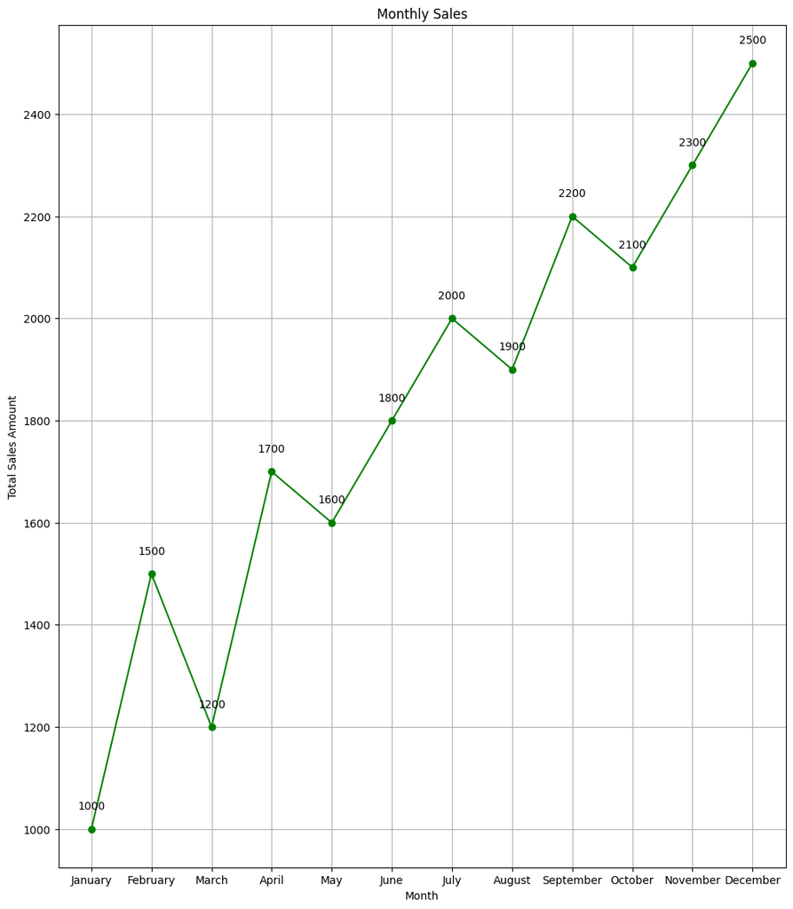

```python
plt.figure(figsize = (12, 14))
plt.plot(x[ : -1], y[ : -1], marker = 'o', linestyle = '-', color = 'g')
plt.title('Monthly Sales')
plt.xlabel('Month')
plt.ylabel('Total Sales Amount')
plt.grid(True)

for i in range(len(x) - 1):
    plt.annotate(f'{y[i]}', (x[i], y[i]), textcoords = "offset points", xytext = (0,18), ha = 'center')

plt.show()
```

1. Sets the figure size for the plot.
2. Creates a line plot with markers at each data point, excluding the last row (total row).
3. Set the title and axis labels.
4. Adds a grid to the plot for better readability.
5. Loop annotates each data point with its sales value, excluding the last row.

### 7. Conclusion

1. Total Sales:
   - The total sales for the year amount to 21,800 units.
2. Highest Sales Month:
   - December has the highest sales with 2,500 units.
3. Lowest Sales Month:
   - January has the lowest sales with 1,000 units.
4. Sales Trend:
   - There is an overall increasing trend in sales throughout the year, with some fluctuations.
   - Sales significantly increase towards the end of the year, peaking in December.